# Annual Highway Report - Data Analysis

2022-07-14

# 1 HM-10: Public road length, miles by ownership

```r
HM_10 <- read_excel("data/hm10.xls", sheet = "A") %>%
  remove_empty() %>%
  select(1, 2, 5, 8, 11) %>%
  slice(-(1:6)) %>%
  rename(state = 1,
         rural_SHA = 2,
         rural_other = 3,
         urban_SHA = 4,
         urban_other = 5) %>%
  filter(state %in% state.name) %>%
  mutate(across(rural_SHA:urban_other, as.numeric),
         SHA_miles = rural_SHA + urban_SHA) %>%
  select(state, SHA_miles)

head(HM_10)
```

```
## # A tibble: 6 × 2
##   state      SHA_miles
##   <chr>          <dbl>
## 1 Alabama       10941.
## 2 Alaska         5637.
## 3 Arizona        6844.
## 4 Arkansas      16454.
## 5 California    15022.
## 6 Colorado       9032.
```

# 2 HM-81: State highway agency-owned public roads; rural and urban miles, estimated lane-miles and daily travel

- Consider 4 factors: state_urban_lane_miles, state_tot_lane_miles, state_urban_dvmt, state_tot_dvmt.
- Calculate percentage of urban dvmt in each state
- Calculate percentage of urban lane miles in each state
- Indexing the above 2 percentages against national levels

This approach is inspired by the [California Policy Center report](https://californiapolicycenter.org/californias-transportation-future-part-four-the-common-road/), which argues that: *“The idea that road construction costs more in urban areas can be attributed to several interrelated factors: Land values are typically greater in densely populated areas. Construction challenges are greater in urban areas where it is more likely that existing structures may have to be acquired and demolished to permit road construction or widening. Labor costs are typically higher in urban areas. Urbanized regions also are likely to have more local restrictions on development, leading to more costly permitting processes and higher fees. There are other key factors influencing road construction costs – for example, climate and topography – but urbanization is easily quantifiable and likely the most significant of them.”*

However, it seems that the report got mixed up between “total lane miles” and daily miles travelled. We present here both ways of using lane miles and dmt for discussion.

```r
HM_81 <- read_excel("data/hm81.xls", sheet  = "A") %>%
  remove_empty() %>%
  rename(state = 1,
         state_urban_lane_miles = 10,
         state_urban_dvmt = 11,
         state_tot_lane_miles = 17,
         state_tot_dvmt = 18) %>%
  select(state, state_urban_lane_miles, state_urban_dvmt, state_tot_lane_miles, state_tot_dvmt) %>%
  slice(-(1:7)) %>%
  mutate(across(state_urban_lane_miles:state_tot_dvmt, as.numeric)) %>%

  # calculate percentage
  mutate(pct_urban_dvmt = state_urban_dvmt/state_tot_dvmt,
         pct_urban_lane_miles = state_urban_lane_miles/state_tot_lane_miles) %>%
  filter(state %in% state.name) %>%

  # national
  mutate(US_pct_urban_dvmt = sum(state_urban_dvmt)/ sum(state_tot_dvmt),
         US_pct_urban_lane_miles = sum(state_urban_lane_miles)/sum(state_tot_lane_miles)) %>%

  # index - relative to national level
  mutate(urban_dvmt_index =  (pct_urban_dvmt/US_pct_urban_dvmt),
         urban_lane_miles_index = (pct_urban_lane_miles/US_pct_urban_lane_miles)) %>%
  select(-c(US_pct_urban_dvmt, US_pct_urban_lane_miles))

head(HM_81) %>% select(1, 6:9)
```

```
## # A tibble: 6 × 5
##   state      pct_urban_dvmt pct_urban_lane_mi… urban_dvmt_index urban_lane_mile…
##   <chr>               <dbl>              <dbl>            <dbl>            <dbl>
## 1 Alabama             0.545              0.315            0.856            1.12
## 2 Alaska              0.590              0.151            0.927            0.541
## 3 Arizona             0.596              0.293            0.937            1.05
## 4 Arkansas            0.480              0.187            0.754            0.667
## 5 California          0.779              0.476            1.22             1.70
## 6 Colorado            0.624              0.255            0.981            0.909
```

# 3 SF-4: Disbursements for state-administered highways (thousands of dollars)

- Using 4 factors: capital disbursements, maintenance disbursements, administrative disbursements, and other disbursements (combined of Highway Law Enforcement and Safety, Interest, and Bond Retirements)

*Adjusting each of the 4 category of disbursements in 3 ways*: (Note: Numbers are multiple with 1000 before adjusted) * Cost of living index * urban_dvmt_index index * urban_lane_miles_index

Note: the 2020 numbers for some reason exactly match the 2019 numbers? These adjustment impacts states’ spending differently. (See graphs below for more detail)

```r
SF_4 <- read_excel("data/sf4.xlsx", sheet = "A") %>%
  remove_empty() %>%
  select(1:7) %>%
  rename(state = 1,
         capital_disbursement = 2,
         maintenance_disbursement = 3,
         admin_disbursement = 4) %>%
  slice(-(1:6)) %>%

  mutate(state = str_replace_all(state, "[:punct:]", ""),    #remove all special characters
         state = str_replace_all(state, "[:digit:]", ""),    #remove all numbers
         state = str_trim(state),
         across(2:7, as.numeric)) %>%

# unit in original file is thousand dollars
  mutate(other_disbursment = rowSums(across(5:7)),
         capital_disbursement = capital_disbursement*1000,
         maintenance_disbursement = maintenance_disbursement * 1000,
         admin_disbursement = admin_disbursement * 1000,
         other_disbursment = other_disbursment * 1000) %>%
  filter(state %in% state.name) %>% select(-c(5:7))

# Cost of living index
coli <- read.csv("data/coli_meric.csv") %>%
  clean_names() %>%
  select(state, coli_index) %>%
  mutate(coli_index = coli_index/100)

# 4 cat x Adjusted for 3 factors: cost of living, urban_dvmt_index, urban_lane_miles_index + keep 4 cat original -> 17 cols
SF_4_adjusted <- SF_4 %>%
  left_join(coli) %>%
  left_join(HM_81 %>% select(state,  urban_dvmt_index, urban_lane_miles_index)) %>%

  mutate(across(2:5, ~ .x/coli_index, .names = "{.col}_coli_index")) %>%
  mutate(across(2:5, ~.x/urban_dvmt_index, .names = "{.col}_urban_dvmt_index")) %>%
  mutate(across(2:5, ~.x/urban_lane_miles_index, .names = "{.col}_urban_lanemiles_index")) %>%
  select(-c(coli_index, urban_dvmt_index, urban_lane_miles_index))
```

Examples of how capital_disbursement is adjusted in 10 states that have highest/lowest capital_disbursement

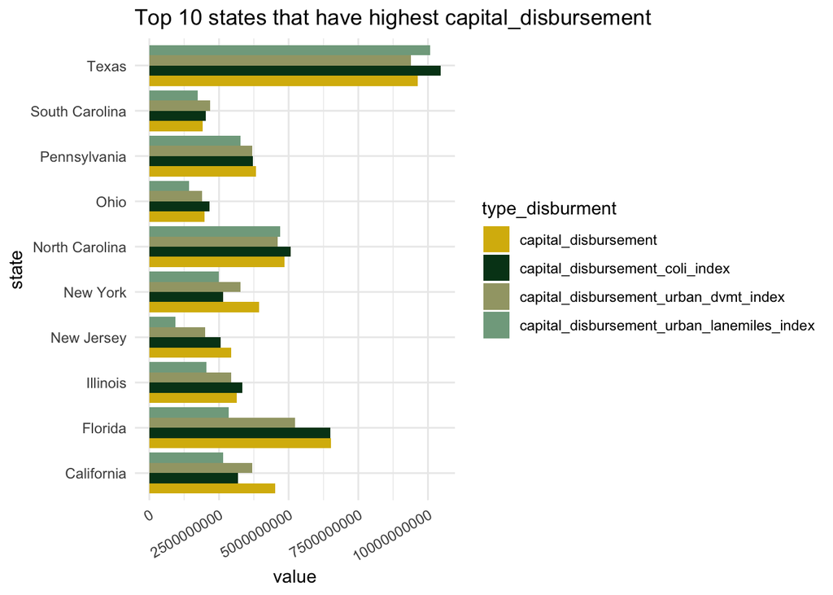

```r
SF_4_adjusted %>% arrange(desc(capital_disbursement)) %>% slice(1:10) %>%
  select(state, capital_disbursement, capital_disbursement_coli_index, capital_disbursement_urban_dvmt_index, capital_disbursement_urban_lanemiles_index) %>%
  pivot_longer(cols = 2:5, names_to = "type_disburment", values_to = "value") %>%
  ggplot(aes(state, value, group = type_disburment, fill = type_disburment)) +
  geom_col(position = "dodge") +
  coord_flip() +
  scale_fill_manual(values = wesanderson::wes_palette("Cavalcanti1")) +
  theme_minimal()+
  labs(title = "Top 10 states that have highest capital_disbursement") +

  theme(legend.position = "right",
        axis.text.x = element_text(angle = 30, vjust = 1, hjust=1))
```

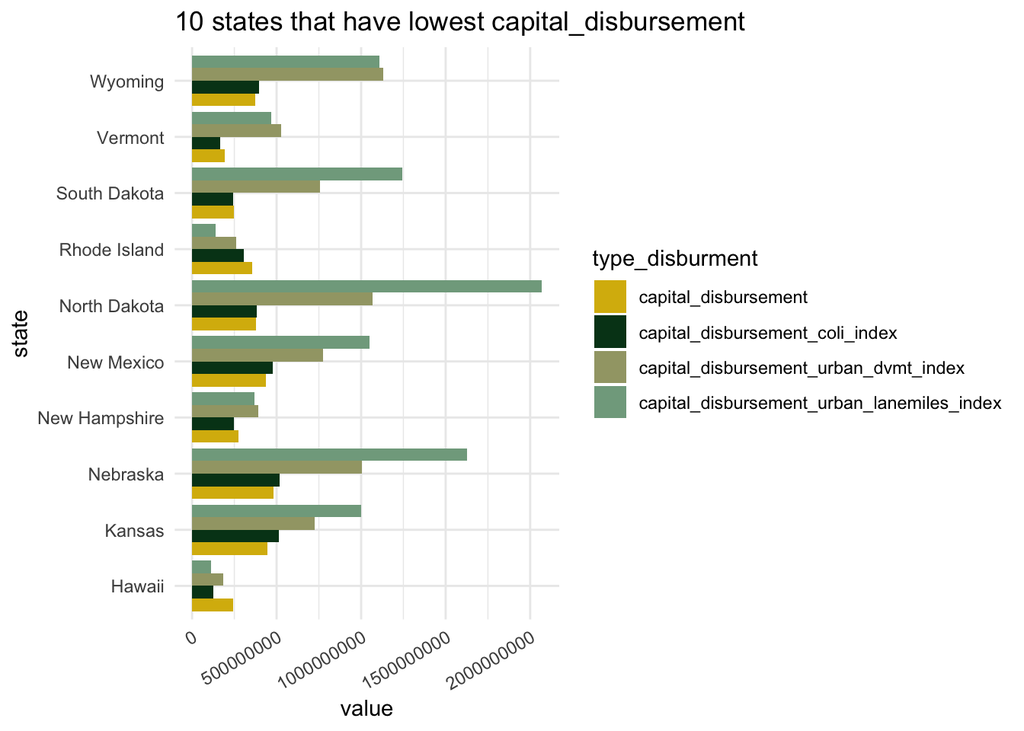

```r
SF_4_adjusted %>% arrange(capital_disbursement) %>% slice(1:10) %>%
  select(state, capital_disbursement, capital_disbursement_coli_index, capital_disbursement_urban_dvmt_index, capital_disbursement_urban_lanemiles_index) %>%
  pivot_longer(cols = 2:5, names_to = "type_disburment", values_to = "value") %>%
  ggplot(aes(state, value, group = type_disburment, fill = type_disburment)) +
  geom_col(position = "dodge") +
  coord_flip() +
scale_fill_manual(values = wesanderson::wes_palette("Cavalcanti1")) +
    labs(title = "10 states that have lowest capital_disbursement") +
  theme_minimal()+
    theme(legend.position = "right",
        axis.text.x = element_text(angle = 30, vjust = 1, hjust=1))
```

# 4 HM-64: Miles by measured pavement roughness

Rural Interstate pavement, urban Interstate pavement, and rural OPA pavement, and urban OPA pavement category

```r
HM64_rural_interstate <- read_excel("data/hm64.xls", sheet = "A") %>%
  remove_empty() %>%
  select(1, 8:11) %>%
  rename(state = 1,
         rural_interstate_171_194 = 2,
         rural_interstate_195_220 = 3,
         rural_interstate_above_220 = 4,
         rural_interstate_total = 5) %>%
  slice(-(1:7)) %>%
  filter(state %in% state.name) %>%
  mutate(across(rural_interstate_171_194:rural_interstate_total, as.numeric),
         rural_interstate_above_170 = rural_interstate_171_194 + rural_interstate_195_220 + rural_interstate_above_220)


HM64_urban_interstate <- read_excel("data/hm64.xls", sheet = "C") %>%
  remove_empty() %>%
  select(1, 8:11) %>%
  rename(state = 1,
         urban_interstate_171_194 = 2,
         urban_interstate_195_220 = 3,
         urban_interstate_above_220 = 4,
         urban_interstate_total = 5) %>%
  slice(-(1:7)) %>%
  filter(state %in% state.name) %>%
  mutate(across(urban_interstate_171_194:urban_interstate_total, as.numeric),
         urban_interstate_above_170 = urban_interstate_171_194 + urban_interstate_195_220 + urban_interstate_above_220)


HM64_rural_OPA <- read_excel("data/hm64.xls", sheet = "B") %>%
  remove_empty() %>%
  select(1, 20:21) %>%
  rename(state = 1,
         rural_OPA_above_220 = 2,
         rural_OPA_total = 3) %>%
  slice(-(1:7)) %>%
  filter(state %in% state.name) %>%
  mutate(across(rural_OPA_above_220:rural_OPA_total, as.numeric))


HM64_urban_OPA <- read_excel("data/hm64.xls", sheet = "D") %>%
  remove_empty() %>%
  select(1, 20:21) %>%
  rename(state = 1,
         urban_OPA_above_220 = 2,
         urban_OPA_total = 3) %>%
  slice(-(1:7)) %>%
  filter(state %in% state.name) %>%
  mutate(across(urban_OPA_above_220:urban_OPA_total, as.numeric))

# Combined HM-64: Miles by measured pavement roughness
HM64 <- HM64_rural_interstate %>%
  left_join(HM64_rural_OPA) %>%
  left_join(HM64_urban_interstate) %>%
  left_join(HM64_urban_OPA) %>%
  select(state,
         rural_interstate_above_170,
         rural_interstate_total,
         rural_OPA_above_220,
         rural_OPA_total,
         urban_interstate_above_170,
         urban_interstate_total,
         urban_OPA_above_220,
         urban_OPA_total)
head(HM64)
```

```
## # A tibble: 6 × 9
##   state      rural_interstate… rural_interstat… rural_OPA_above… rural_OPA_total
##   <chr>                  <dbl>            <dbl>            <dbl>           <dbl>
## 1 Alabama                 8.48             571.             7.13           2047.
## 2 Alaska                 94.5              982.            65.8             478.
## 3 Arizona                20.2              909.            13.7            1241.
## 4 Arkansas               11.6              439.            33.7            1877.
## 5 California             54.6             1209.            77.2            3333.
## 6 Colorado               53.9              648.            27.0            2569.
## # … with 4 more variables: urban_interstate_above_170 <dbl>,
## #   urban_interstate_total <dbl>, urban_OPA_above_220 <dbl>,
## #   urban_OPA_total <dbl>
```

# 5 FI-20: Persons fatally injured in motor vehicle crashes

Including:

- Rural interstate, OFA, OPE, total
- urban interstate, OFA, OPE, total
- total fatality
- rural_other_fatalities: sum of minor arterials, minor collector, major collector, and local roads in rural
- urban_other_fatalities: sum of minor arterials, minor collector, major collector, and local roads in urban

Note: the last 2 are included in total of rural and urban already.

```r
FI_20 <- read_excel("data/fi20.xls", sheet = "A") %>%
  remove_empty() %>%
  rename(
    state = 1,
    rural_interstate_fatalities = 2,
    rural_OFE_fatalities = 3,
    rural_OPA_fatalities = 4,
    rural_total_fatalities = 9,

    urban_interstate_fatalities = 10,
    urban_OFE_fatalities = 11,
    urban_OPA_fatalities = 12,
    urban_total_fatalities = 17,

    total_fatalities = 19
  ) %>%
  filter(state %in% state.name) %>%
  mutate(across(2:19, as.numeric)) %>%
  mutate(rural_other_fatalities = rowSums(across(5:8)), # minor arterials, minor collector, major collector, and local roads in rural
         urban_other_fatalities = rowSums(across(13:16))) %>% # minor arterials, minor collector, major collector, and local roads in urban
  select(-c(5:8, 13:16, 18))

head(FI_20)
```

```
## # A tibble: 6 × 12
##   state      rural_interstat… rural_OFE_fatal… rural_OPA_fatal… rural_total_fat…
##   <chr>                 <dbl>            <dbl>            <dbl>            <dbl>
## 1 Alabama                  44                1              123              518
## 2 Alaska                   16                0                1               38
## 3 Arizona                  80                1               86              330
## 4 Arkansas                 54                5               18              205
## 5 California              140               59              296             1175
## 6 Colorado                 27                5               85              236
## # … with 7 more variables: urban_interstate_fatalities <dbl>,
## #   urban_OFE_fatalities <dbl>, urban_OPA_fatalities <dbl>,
## #   urban_total_fatalities <dbl>, total_fatalities <dbl>,
## #   rural_other_fatalities <dbl>, urban_other_fatalities <dbl>
```

# 6 VM-2: Annual vehicle miles

NOTE: VM2 file says unit = millions, should be thousand? –> currently multiple each columns by 1000

- rural_other_VMT: sum of minor arterials, minor collector, major collector, and local roads in rural
- urban_other_VMT: sum of minor arterials, minor collector, major collector, and local roads in urban

```r
VM_2 <- read_excel("data/vm2.xls", sheet = "A") %>%
  rename(state = 1,
    rural_interstate_VMT = 2,
    rural_OFE_VMT = 3,
    rural_OPA_VMT = 4,
    rural_total_VMT = 9,

    urban_interstate_VMT = 10,
    urban_OFE_VMT = 11,
    urban_OPA_VMT = 12,
    urban_total_VMT = 17,

    total_VMT = 18) %>%
  filter(state %in% state.name) %>%
  mutate(across(2:18, as.numeric)) %>%
  mutate(
    rural_other_VMT = rowSums(across(5:8)),
    urban_other_VMT = rowSums(across(13:16))
  ) %>%
  select(-c(5:8, 13:16)) %>%
  mutate(across(2:12)*1000)
head(VM_2)
```

```
## # A tibble: 6 × 12
##   state      rural_interstate_VMT rural_OFE_VMT rural_OPA_VMT rural_total_VMT
##   <chr>                     <dbl>         <dbl>         <dbl>           <dbl>
## 1 Alabama                6130420.            0       5464506.       27813551.
## 2 Alaska                  741867.            0        250354.        2482957.
## 3 Arizona                6764795.       100252.      3468340.       15767882.
## 4 Arkansas               3724145.       273169.      3449644        16305247.
## 5 California            15891918.      5859591.     10847276.       55380943.
## 6 Colorado               4513507.       240404.      4317439.       15040153.
## # … with 7 more variables: urban_interstate_VMT <dbl>, urban_OFE_VMT <dbl>,
## #   urban_OPA_VMT <dbl>, urban_total_VMT <dbl>, total_VMT <dbl>,
## #   rural_other_VMT <dbl>, urban_other_VMT <dbl>
```

# 7 Bridge data

```r
bridge_raw <- read_excel("data/fccount21.xlsx", sheet = "2021")

bridge_total <- bridge_raw[1:58,] %>%
  rename(state = 1) %>%
  mutate(state = str_to_title(state)) %>%
  filter(state %in% state.name) %>%
  mutate(across(2:13, as.numeric)) %>%
  mutate(total_bridges = rowSums(across(where(is.numeric)))) %>%
  select(state, total_bridges)

bridge_poor <- bridge_raw[180:nrow(bridge_raw),] %>%
  rename(state = 1) %>%
  mutate(state = str_to_title(state)) %>%
  filter(state %in% state.name) %>%
  mutate(across(2:13, as.numeric)) %>%
  mutate(total_poor_bridges = rowSums(across(where(is.numeric)))) %>%
  select(state, total_poor_bridges)

bridge_data <- bridge_total %>%
  left_join(bridge_poor)
head(bridge_data)
```

```
## # A tibble: 6 × 3
##   state      total_bridges total_poor_bridges
##   <chr>              <dbl>              <dbl>
## 1 Alabama            16164                586
## 2 Alaska              1632                134
## 3 Arizona             8467                117
## 4 Arkansas           12941                679
## 5 California         25737               1493
## 6 Colorado            8869                469
```

# 8 Congestion data

## 8.1 Using UMR data

```r
umr_2020 <- import("data/Copy of complete-data-2021-umr-by-tti.xlsx", sheet = "urban areas")
vehicle_miles_data <- read_excel("data/HM-74 Daily Vehicle Miles Travelled.xlsx", sheet = "Sheet1")

#Clean umr data
state_list <- paste0(state.abb, collapse = "|")   #use this to remove state abbreviations later

umr_2020_clean <- umr_2020 %>%
  filter(Year == "2020") %>%
  rename(
    population = Population...6,
    auto_commuters = Auto, # original column:  Auto Commuter (000)
    total_hours_delay = `Annual Hours of Delay`,
    hours_delay_perAuto_commuter = `...24`, # original column: per Auto Commuter
    first_state = Primary,
    urban_area = `Urban Area`,
  ) %>%
  mutate(auto_commuters = as.numeric(auto_commuters)*1000,
         population = as.numeric(population)*1000) %>%

  select(urban_area, first_state, population, auto_commuters, total_hours_delay, hours_delay_perAuto_commuter) %>%
  mutate(across(population:hours_delay_perAuto_commuter, as.numeric)) %>%

  mutate(urban_area = str_remove_all(urban_area, " City"),
         city = str_remove_all(urban_area, state_list),    #remove state abbreviations
         city = str_remove(city, "-+$"),
         city = str_squish(city),

         # split first-second-third city ; first-second state--> each will have proportion of daily vehicle mile traveled corresponding to each state.
         first_city = str_split(city, "-", simplify = T)[,1],
         second_city = str_split(city, "-", simplify = T)[,2],
         third_city = str_split(city, "-", simplify = T)[,3]
  )
```

## 8.2 HM-74 Daily Vehicle Miles Travelled

UMR provides data for urban area. Some areas run across states. This is to be parsed out into state data using the following steps in HM-74 Daily Vehicle Miles Travelled:

- Parsing first city, first state
- Calculate `total_dmvt`, total daily vehicle mile travelled of each urban area
- Calculate the percentage of daily vehicel mile travelled of each state

```r
vehicle_miles_data_clean <- vehicle_miles_data %>%
  clean_names() %>%
  mutate(first_city = str_replace(area, ",.*",""),
         first_city = str_replace(first_city, "-.*",""),
         first_city = str_replace(first_city, " City", ""),
         first_state = str_extract(area, ", .."),
         first_state = str_replace(first_state, ", ", ""),
         total_dmvt = interstate_total + ofe_total + opa_total + ma_total   #exclude "unreported" dvm based on the documentation and past results. Can change this later if we decide to include this number.
  ) %>%
  group_by(area) %>%
  mutate(dmvt_pct = total_dmvt/sum(total_dmvt)) %>%
  ungroup() %>%
  select(area, first_city,  first_state, state, dmvt_pct) %>%
  #fix some city names to match the umr data
  mutate(first_city = replace(first_city, first_city == "Urban Honolulu", "Honolulu"),
         first_city = replace(first_city, first_city == "Louisville/Jefferson County", "Louisville"),
         first_city = replace(first_city, first_city == "East Stroudsburg", "East Stoudsburg"),
         first_city = replace(first_city, first_city == "El Paso de Robles (Paso Robles)", "El Paso de Robles"),
         first_city = replace(first_city, first_city == "Homosassa Springs", "Homosassa Spr"),
         first_city = replace(first_city, first_city == "Round Lake Beach", "Round Lake Bch"),
         first_state = replace(first_state, first_city == "Round Lake Bch", "WI"))
```

- Next, join UMR and HM-74. There are 134 cases of inter-state urban areas, i.e. percentage of dmvt < 1.
- Calculate the percentage of auto commuters in each state
- Calculate the percentage of delay hours in each state

Finally:

- Calculate total number of commuter in each state
- Calculate total delay hours in each state
- Calculate average delay hours in each state

```r
state_names <- data.frame(state.abb, state.name)     #to get state full names

congestion_data <- umr_2020_clean %>%
  left_join(vehicle_miles_data_clean, by = c("first_city", "first_state")) %>%
  mutate(dmvt_pct = ifelse(is.na(dmvt_pct), 1, dmvt_pct),
         state = ifelse(is.na(state), first_state, state)) %>%
  select(area, state, dmvt_pct, auto_commuters, total_hours_delay, hours_delay_perAuto_commuter) %>%
 #filter(dmvt_pct < 1) %>% # there are 134 cases of inter-state cities

 # Calculate average delay hours in each state
  mutate(state_pct_auto_commuters = auto_commuters * dmvt_pct,
         state_pct_delay_hours = state_pct_auto_commuters * hours_delay_perAuto_commuter) %>%
  group_by(state) %>%
  summarise(state_tot_commuter = round(sum(state_pct_auto_commuters)),
            state_tot_delay_hours = sum(state_pct_delay_hours)) %>%
  mutate(state_avg_delay_hours = round(state_tot_delay_hours/state_tot_commuter,1)) %>%


  select(state, state_avg_delay_hours) %>%
  left_join(state_names, by = c("state" = "state.abb")) %>%
  select(-state) %>%
  rename(state = state.name) %>%
  filter(!is.na(state))

#The result is not identical, but very similar to other method solving for delay & remain time.
#congestion_data_summary_truongJune28 %>% select(state, state_avg_delay_hours) %>% arrange(state_avg_delay_hours)
head(congestion_data)
```

```
## # A tibble: 6 × 2
##   state_avg_delay_hours state
##                   <dbl> <chr>
## 1                  17.1 Alaska
## 2                  16.2 Alabama
## 3                  20.4 Arkansas
## 4                  22.2 Arizona
## 5                  31.3 California
## 6                  22.8 Colorado
```

# 9 Joining all data

The combined data has the following components:

```r
AHR_states <- list(HM_10,
                 HM_81,
                 SF_4_adjusted,
                 HM64,
                 FI_20,
                 VM_2,
                 bridge_data,
                 congestion_data) %>%
  reduce(left_join, by = "state")

#Calculate national metrics
AHR_national <- AHR_states %>%
  summarise(across(2:ncol(AHR_states), sum)) %>%
  mutate(state = "United States")

AHR_data <- bind_rows(AHR_states, AHR_national)

colnames(AHR_data)
```

```
##  [1] "state"
##  [2] "SHA_miles"
##  [3] "state_urban_lane_miles"
##  [4] "state_urban_dvmt"
##  [5] "state_tot_lane_miles"
##  [6] "state_tot_dvmt"
##  [7] "pct_urban_dvmt"
##  [8] "pct_urban_lane_miles"
##  [9] "urban_dvmt_index"
## [10] "urban_lane_miles_index"
## [11] "capital_disbursement"
## [12] "maintenance_disbursement"
## [13] "admin_disbursement"
## [14] "other_disbursment"
## [15] "capital_disbursement_coli_index"
```

[output cut: 44 more lines]

## 9.1 Disbursement Adjustment & Its Effects

Three methods of adjustment have substantial impact on the disbursement per unit of lane miles or VMT.

method 0: no adjustment. Each category of disbursement is divided by state total daily vehicle mile travelled

In the following 3 methods, each category of disbursement is first divided by the corresponding index (i.e. adjusted).

method 1: adjusted for cost of living, then divided by state total daily vehicle mile travelled method 2: adjusted for urban_dvmt_index (percentage of urban vmt relatively to national), then divided by state total daily vehicle mile travelled method 3: adjusted for urban_lanemiles_index (percentage of urban lane mile relatively to national), then divided by state total lane miles

Method 3 has the strongest effect.

```r
  disbursment_adjusted <- AHR_data %>%
  # method 0: disbursement not adjusted
  mutate(capital_disbursement = capital_disbursement/state_tot_dvmt,
         maintenance_disbursement = maintenance_disbursement / state_tot_dvmt,
        admin_disbursement = admin_disbursement / state_tot_dvmt,
        other_disbursment = other_disbursment/state_tot_dvmt) %>%

  # 3 methods of disbursement adjusting
  mutate(
    # method 1: adjusted for cost of living - coli index
    capital_disbursement_pervmt_coli = capital_disbursement_coli_index / state_tot_dvmt,
    maintenance_disbursement_pervmt_coli = maintenance_disbursement_coli_index / state_tot_dvmt,
    admin_disbursement_pervmt_coli = admin_disbursement_coli_index / state_tot_dvmt,
    other_disbursment_pervmt_coli = other_disbursment_coli_index/ state_tot_dvmt,

    # method 2: adjusted for urban_dvmt_index (percentage of urban lane mile relatively to national)
    capital_disbursement_per_vmt = capital_disbursement_urban_dvmt_index / state_tot_dvmt,
    maintenance_disbursement_per_vmt = maintenance_disbursement_urban_dvmt_index / state_tot_dvmt,
    admin_disbursement_per_vmt = admin_disbursement_urban_dvmt_index / state_tot_dvmt,
    other_disbursment_per_vmt = other_disbursment_urban_dvmt_index / state_tot_dvmt,

    # method 3: adjusted for urban_lanemiles_index (percentage of urban lane mile relatively to national)
    capital_disbursement_per_lm = capital_disbursement_urban_lanemiles_index / state_tot_lane_miles,
    maintenance_disbursement_per_lm = maintenance_disbursement_urban_lanemiles_index / state_tot_lane_miles,
    admin_disbursement_per_lm = admin_disbursement_urban_lanemiles_index / state_tot_lane_miles,
    other_disbursment_per_lm = other_disbursment_urban_lanemiles_index/ state_tot_lane_miles) %>%

  select(state, capital_disbursement : other_disbursment,
         capital_disbursement_pervmt_coli: other_disbursment_per_lm)
```

Viewing how different methods of adjustment impact capital_disbursement per unit of VMT / or unit of lane miles

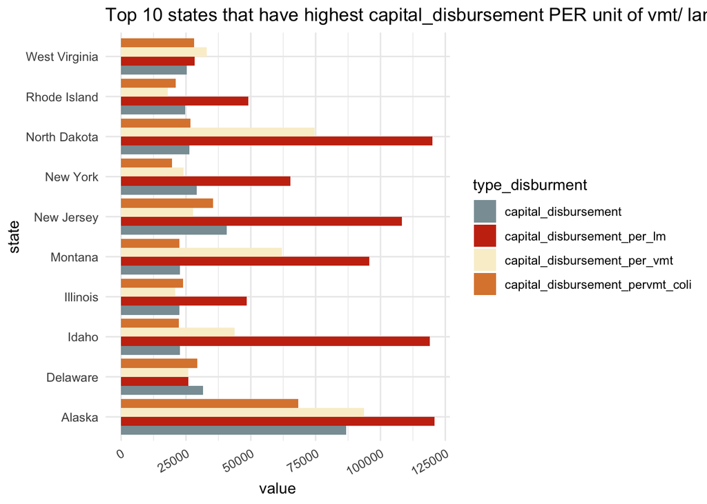

```r
disbursment_adjusted %>% arrange(desc(capital_disbursement)) %>% slice(1:10) %>%
  select(state, capital_disbursement, capital_disbursement_pervmt_coli, capital_disbursement_per_vmt, capital_disbursement_per_lm) %>%
  pivot_longer(cols = 2:5, names_to = "type_disburment", values_to = "value") %>%
  ggplot(aes(state, value, group = type_disburment, fill = type_disburment)) +
  geom_col(position = "dodge") +
  coord_flip() +

  scale_fill_manual(values = wesanderson::wes_palette("Royal1")) +
  theme_minimal()+
  labs(title = "Top 10 states that have highest capital_disbursement PER unit of vmt/ lane miles") +

  theme(legend.position = "right",
        axis.text.x = element_text(angle = 30, vjust = 1, hjust=1))
```

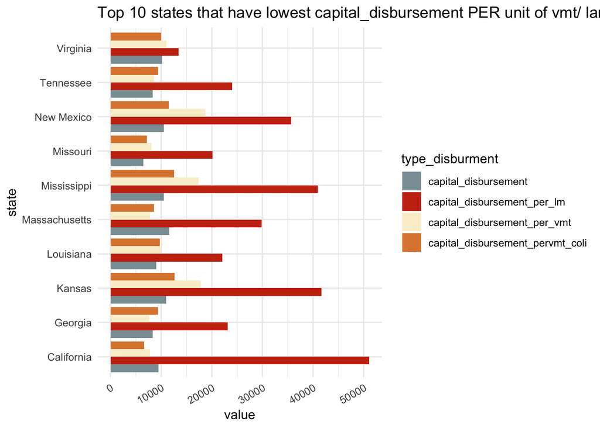

```r
disbursment_adjusted %>% arrange(capital_disbursement) %>% slice(1:10) %>%
  select(state, capital_disbursement, capital_disbursement_pervmt_coli, capital_disbursement_per_vmt, capital_disbursement_per_lm) %>%
  pivot_longer(cols = 2:5, names_to = "type_disburment", values_to = "value") %>%
  ggplot(aes(state, value, group = type_disburment, fill = type_disburment)) +
  geom_col(position = "dodge") +
  coord_flip() +

  scale_fill_manual(values = wesanderson::wes_palette("Royal1")) +
  theme_minimal()+
  labs(title = "Top 10 states that have lowest capital_disbursement PER unit of vmt/ lane miles") +

  theme(legend.position = "right",
        axis.text.x = element_text(angle = 30, vjust = 1, hjust=1))
```

## 9.2 Other 9 Metrics

```r
metrics_9others <- AHR_data %>%
  # SHA ratio
  mutate(SHA_ratio = state_tot_lane_miles / SHA_miles, .after = state_tot_lane_miles) %>%

  mutate(
  # bridge
    poor_bridges_percent = total_poor_bridges / total_bridges * 100,

  # pavement roughness (4 indicators)
    rural_interstate_poor_percent = rural_interstate_above_170 / rural_interstate_total * 100,
    urban_interstate_poor_percent = urban_interstate_above_170 / urban_interstate_total * 100,
    rural_OPA_poor_percent = rural_OPA_above_220 / rural_OPA_total * 100,
    urban_OPA_poor_percent = urban_OPA_above_220 / urban_OPA_total * 100,

  # fatalities  -->  # Question for Baruch: is this satisfying "Let's add a third fatality category that measures the fatality rate on minor arterials, collectors, and local roads in both rural and urban area"
    rural_fatalities_per_100m_VMT = rural_total_fatalities / rural_total_VMT * 100, # rural_total_fatalities already included arterials, collectors and local
    urban_fatalities_per_100m_VMT = urban_total_fatalities / urban_total_VMT * 100,
  ) %>%
  select(state, SHA_ratio, poor_bridges_percent, rural_interstate_poor_percent, urban_interstate_poor_percent, rural_OPA_poor_percent, urban_OPA_poor_percent, rural_fatalities_per_100m_VMT, urban_fatalities_per_100m_VMT, state_avg_delay_hours)

head(metrics_9others)
```

```
## # A tibble: 6 × 10
##   state      SHA_ratio poor_bridges_percent rural_interstate_p… urban_interstat…
##   <chr>          <dbl>                <dbl>               <dbl>            <dbl>
## 1 Alabama         2.72                 3.63                1.49             5.16
## 2 Alaska          2.09                 8.21                9.63             1.69
## 3 Arizona         2.93                 1.38                2.22             2.13
## 4 Arkansas        2.31                 5.25                2.65             5.13
## 5 California      3.46                 5.80                4.52             9.38
## 6 Colorado        2.55                 5.29                8.32             6.64
## # … with 5 more variables: rural_OPA_poor_percent <dbl>,
## #   urban_OPA_poor_percent <dbl>, rural_fatalities_per_100m_VMT <dbl>,
## #   urban_fatalities_per_100m_VMT <dbl>, state_avg_delay_hours <dbl>
```

# 10 Calculate overall scores

With 3 new ways of disbursement adjusting, plus a case when disbursement is kept raw, we have 4 results. Choosing which one is a subject for further considerations.

```r
## Method 0: Not adjusting for disbursement
method0 <- disbursment_adjusted %>% select(state, capital_disbursement, maintenance_disbursement, admin_disbursement, other_disbursment) %>% left_join(metrics_9others) %>%
  pivot_longer(cols = 2:13,
               names_to = "metrics",
               values_to = "value") %>%
  group_by(metrics) %>%
  mutate(relative_score = value / value[state == "United States"]) %>%
  ungroup() %>%
  group_by(state) %>%
  mutate(overall_score = mean(relative_score, na.rm = T)) %>% # Question: want to keep this - all 12 indicators have equal weight?
  ungroup() %>%
  select(state, overall_score) %>%
  filter(state != "United States") %>% distinct() %>%
  mutate(overall_rank_method0 = min_rank(overall_score)) %>%
  select(state, overall_rank_method0)

# method 1: adjusted for cost of living - coli index
method1 <- disbursment_adjusted %>% select(state, capital_disbursement_pervmt_coli, maintenance_disbursement_pervmt_coli, admin_disbursement_pervmt_coli, other_disbursment_pervmt_coli) %>%
  left_join(metrics_9others) %>%
  pivot_longer(cols = 2:14,
               names_to = "metrics",
               values_to = "value") %>%
  group_by(metrics) %>%
  mutate(relative_score = value / value[state == "United States"]) %>%
  ungroup() %>%
  group_by(state) %>%
  mutate(overall_score = mean(relative_score, na.rm = T)) %>% # Question: want to keep this - all 12 indicators have equal weight?
  ungroup() %>%
  select(state, overall_score) %>%
  filter(state != "United States") %>% distinct() %>%
  mutate(overall_rank_method1 = min_rank(overall_score)) %>% arrange(overall_rank_method1) %>%
  select(state, overall_rank_method1)

# method 2: adjusted for urban_dvmt_index (percentage of urban lane mile relatively to national)

method2 <- disbursment_adjusted %>% select(state, capital_disbursement_per_vmt, maintenance_disbursement_per_vmt, admin_disbursement_per_vmt, other_disbursment_per_vmt) %>%
  left_join(metrics_9others) %>%
  pivot_longer(cols = 2:14,
               names_to = "metrics",
               values_to = "value") %>%
  group_by(metrics) %>%
  mutate(relative_score = value / value[state == "United States"]) %>%
  ungroup() %>%
  group_by(state) %>%
  mutate(overall_score = mean(relative_score, na.rm = T)) %>% # Question: want to keep this - all 12 indicators have equal weight?
  ungroup() %>%
  select(state, overall_score) %>%
  filter(state != "United States") %>% distinct() %>%
  mutate(overall_rank_method2 = min_rank(overall_score)) %>% arrange(overall_rank_method2) %>%
  select(state, overall_rank_method2)


# method 3: adjusted for urban_lanemiles_index (percentage of urban lane mile relatively to national)

method3 <- disbursment_adjusted %>% select(state, capital_disbursement_per_lm, maintenance_disbursement_per_lm, admin_disbursement_per_lm, other_disbursment_per_lm) %>%
  left_join(metrics_9others) %>%
  pivot_longer(cols = 2:14,
               names_to = "metrics",
               values_to = "value") %>%
  group_by(metrics) %>%
  mutate(relative_score = value / value[state == "United States"]) %>%
  ungroup() %>%
  group_by(state) %>%
  mutate(overall_score = mean(relative_score, na.rm = T)) %>% # Question: want to keep this - all 12 indicators have equal weight?
  ungroup() %>%
  select(state, overall_score) %>%
  filter(state != "United States") %>% distinct() %>%
  mutate(overall_rank_method3 = min_rank(overall_score)) %>% arrange(overall_rank_method3) %>%
  select(state, overall_rank_method3)

ranking_data <- method0 %>% left_join(method1) %>% left_join(method2) %>% left_join(method3) %>% arrange(state) %>%
  mutate(report_26th_rank = c(28, 48, 29, 17, 45, 37, 31, 44, 41, 14, 47, #hawaii
                               8, 40, 32, 22, 7, 4, 35, 33, 38, #Maryland
                              43, 34, 18, 15, 3, 11, 21, 20, 19, 50, #New Jersey
                              27, 46, 5, 1, 24, 36, 25, 39, 49, 23, #South Carolina
                              9, 19, 16, 6, 13, 2, 30, 29, 26, 12
  )) %>%
  pivot_longer(cols = 2:6,
               names_to = "rank",
               values_to = "value")
head(metrics_9others)
```

```
## # A tibble: 6 × 10
##   state      SHA_ratio poor_bridges_percent rural_interstate_p… urban_interstat…
##   <chr>          <dbl>                <dbl>               <dbl>            <dbl>
## 1 Alabama         2.72                 3.63                1.49             5.16
## 2 Alaska          2.09                 8.21                9.63             1.69
## 3 Arizona         2.93                 1.38                2.22             2.13
## 4 Arkansas        2.31                 5.25                2.65             5.13
## 5 California      3.46                 5.80                4.52             9.38
## 6 Colorado        2.55                 5.29                8.32             6.64
## # … with 5 more variables: rural_OPA_poor_percent <dbl>,
## #   urban_OPA_poor_percent <dbl>, rural_fatalities_per_100m_VMT <dbl>,
## #   urban_fatalities_per_100m_VMT <dbl>, state_avg_delay_hours <dbl>
```

## 10.1 Viewing differences in ranking

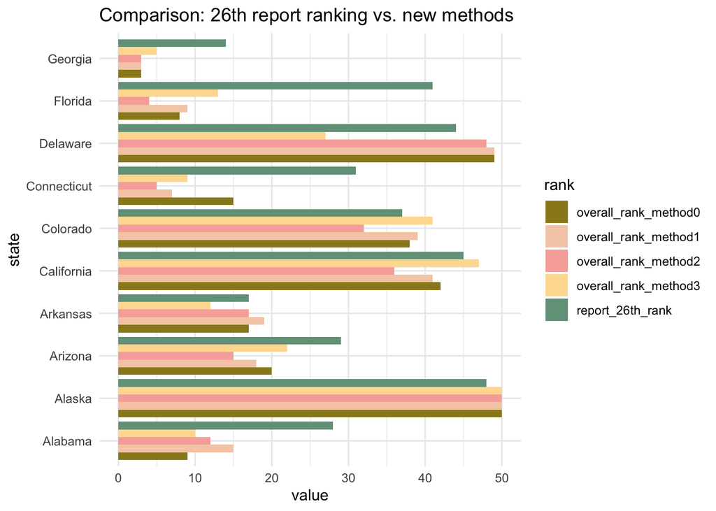

```r
library(patchwork)

ranking_data %>% slice(1:50) %>%
  ggplot(aes(state, value, group = rank, fill = rank)) +
  geom_col(position = "dodge") +
  coord_flip() +
  theme_minimal() +
  labs(title = "Comparison: 26th report ranking vs. new methods") +
  theme(legend.position = "right") +
  scale_fill_manual(values = wesanderson::wes_palette("Royal2"))
```

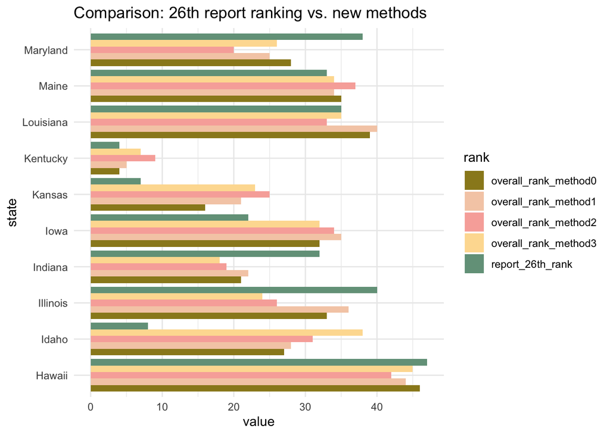

```r
ranking_data %>% slice(51:100) %>%
  ggplot(aes(state, value, group = rank, fill = rank)) +
  geom_col(position = "dodge") +
  coord_flip() +
  theme_minimal() +
  labs(title = "Comparison: 26th report ranking vs. new methods") +
  theme(legend.position = "right") +
  scale_fill_manual(values = wesanderson::wes_palette("Royal2"))
```

# 11 Letter rating

We’re aware that ranking is quite sensitive to different choices of methodology. One option worth consideration is using letter rating instead of numeric ranking. For the lack of “objective” criteria to assign letters to the values, and also for simplicity, the overall ranking is binned in 10 bins, from A+ to D.

```r
final_ranking_letters <- ranking_data %>% arrange(state) %>%
  mutate(letter_rating = case_when(value <= 5 ~ "A+",
                                   value <= 10 ~ "A",
                                   value <= 15 ~ "A-",
                                   value <= 20 ~ "B+",
                                   value <= 25 ~ "B",
                                   value <= 30 ~ "B-",
                                   value <= 35 ~ "C+",
                                   value <= 40 ~ "C",
                                   value <= 45 ~ "C-",
                                   TRUE ~ "D")) %>%
  pivot_wider(names_from = rank,
              values_from = value)

write.csv(final_ranking_letters, "final_ranking_letters.csv")
```